# Assignment_1

Wagner Quiros Pereira

4/25/2017

# R Markdown Practice

**Monthly precipitation**

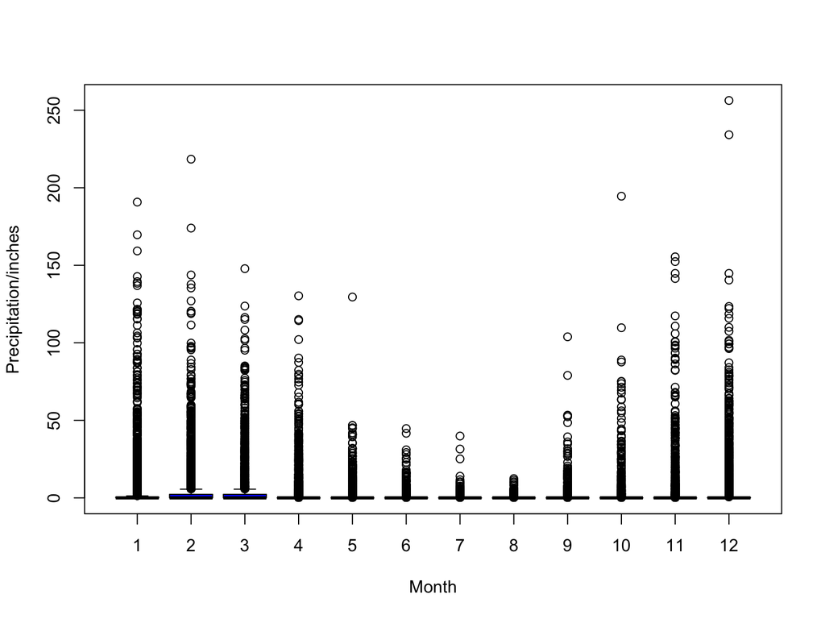

```r
climate = read.table("clim.txt", header=T)
boxplot(climate$rain~climate$month,
  ylab="Precipitation/inches",
  xlab="Month", col="blue")
```

*We observe how the summer months from June to August, (6,7 and 8 respectively) show the lowest precipitation in inches*

**Monthly minimum average temperature**

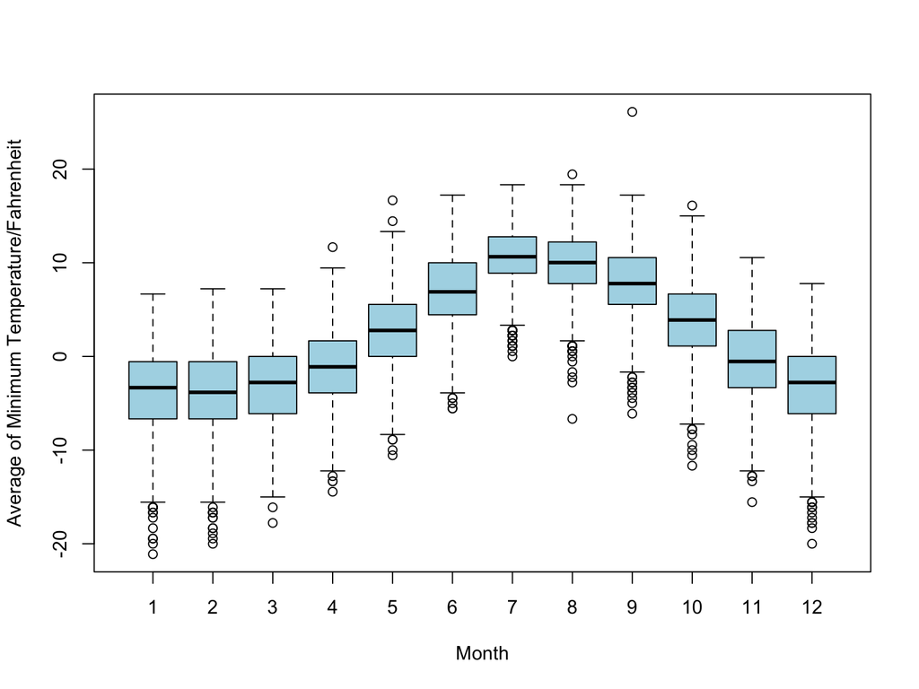

```r
climate = read.table("clim.txt", header=T)
boxplot(climate$tmin~climate$month,
  ylab="Average of Minimum Temperature/Fahrenheit",
  xlab="Month", col="lightblue")
```

**Monthly maximum average temperature**

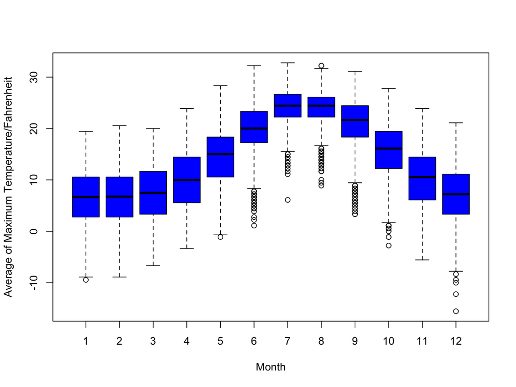

```r
climate = read.table("clim.txt", header=T)
boxplot(climate$tmax~climate$month,
  ylab="Average of Maximum Temperature/Fahrenheit",
  xlab="Month", col="blue")
```

**The highest temperature averages using historical minimum documented values are observed during the summer months from June to August (6,7,8 respectively)*

**Annual rain A**

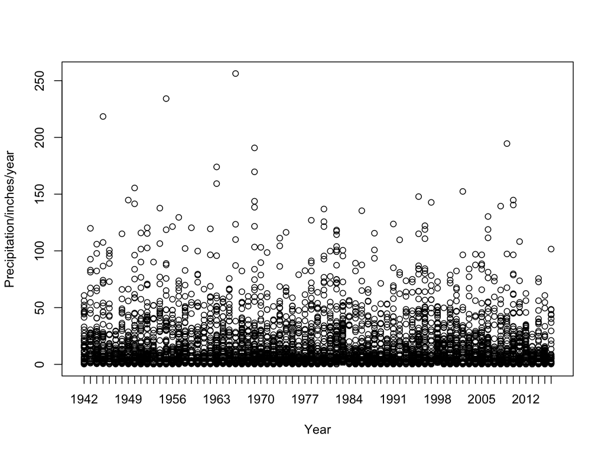

```r
rainfall= read.table("clim.txt", header=T)
boxplot(rainfall$rain~rainfall$year,
  ylab="Precipitation/inches/year",
  xlab="Year", col="orange")
```

**Annual Mean Rainfall**

```r
YearMeanST <- aggregate (rainfall$rain ~ year, data = rainfall, FUN = function(x) {c(MEAN = mean(x), SD= sd (x))})
names(YearMeanST)
```

```
## [1] "year"          "rainfall$rain"
```

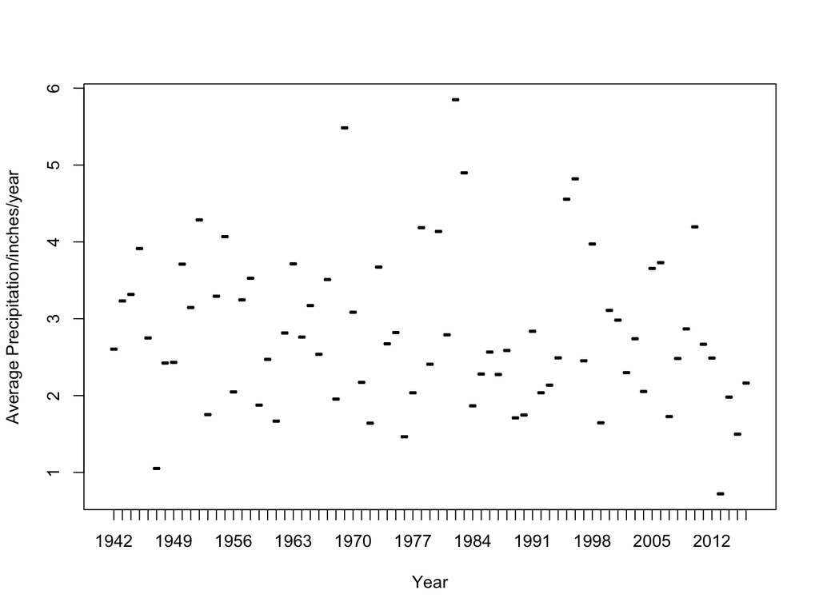

```r
YearMeanSTTable <- do.call(data.frame, YearMeanST)
colnames(YearMeanSTTable) <- c("Year", "Mean", "SD")
View(YearMeanSTTable)
boxplot(YearMeanSTTable$Mean~YearMeanSTTable$Year,
 ylab="Average Precipitation/inches/year",
 xlab="Year", col="blue")
```

**Wettest year using the mean**

```r
result=which.max(YearMeanSTTable$Mean)
YearMeanSTTable[result,]
```

```
##    Year     Mean       SD
## 41 1982 5.850351 18.62009
```

*The historically wettest year between 1942 to 2016 was 1982*

**Driest year using the mean**

```r
result=which.min(YearMeanSTTable$Mean)
YearMeanSTTable[result,]
```

```
##    Year      Mean       SD
## 72 2013 0.7216384 2.850297
```

**The historically driest year from 1942 to 2016 was 2013*

**Wet and Dry Season Picture from Guanacaste, Costa Rica. Tropical Dry Forest**

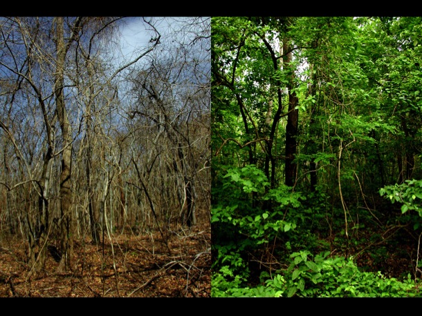

**Subsetting seasons**

```r
View(climate)
range(climate$month)
```

```
## [1]  1 12
```

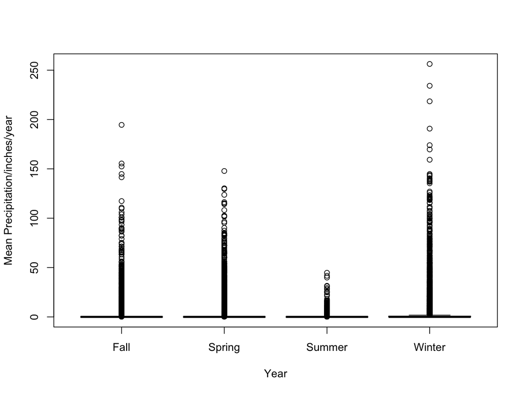

```r
climate$period <- ifelse(climate$month %in% c(3,4,5),"Spring",
ifelse(climate$month %in% c(6,7,8), "Summer",
ifelse(climate$month %in% c(9,10,11), "Fall", "Winter")))
boxplot(climate$rain~climate$period,
ylab="Mean Precipitation/inches/year",
xlab="Year", col="blue")
```

```r
SeasonMeanSD <- aggregate (climate$rain ~ period, data = climate, FUN = function(x) {c(MEAN = mean(x), SD= sd (x))})
names(SeasonMeanSD)
```

```
## [1] "period"       "climate$rain"
```

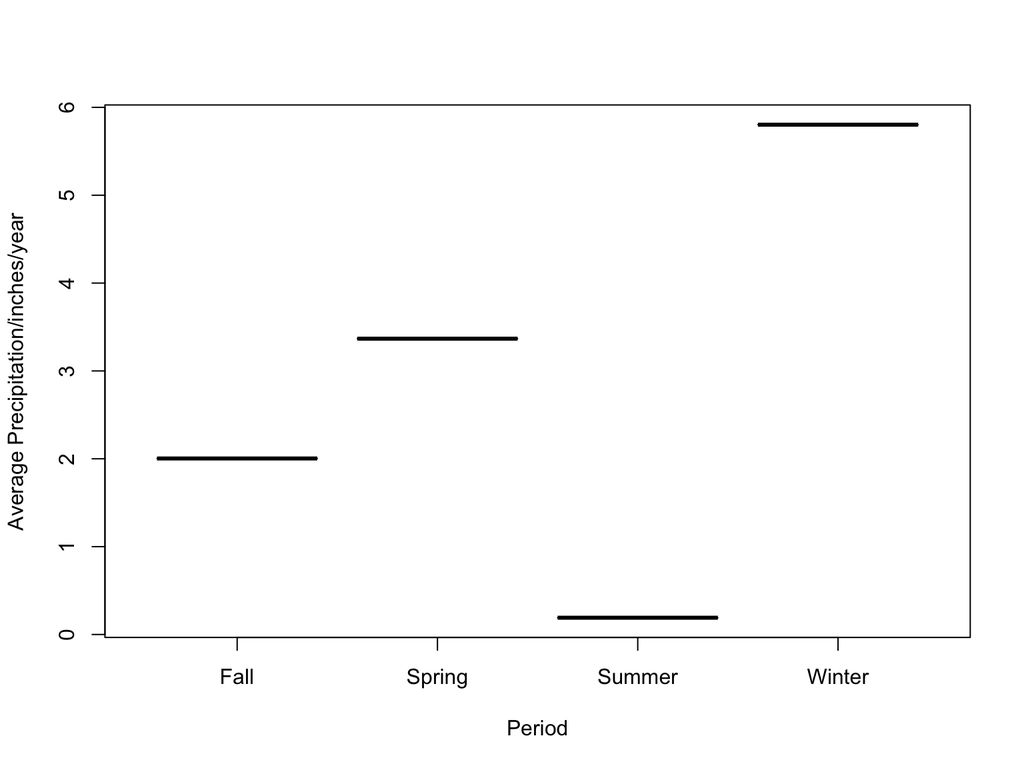

```r
SeasonMeanSTTable <- do.call(data.frame, SeasonMeanSD)
colnames(SeasonMeanSTTable) <- c("Period", "Mean", "SD")
View(SeasonMeanSTTable)
boxplot(SeasonMeanSTTable$Mean~SeasonMeanSTTable$Period,
 ylab="Average Precipitation/inches/year",
 xlab="Period", col="blue")
```

**Driest season using the mean**

```r
result=which.min(SeasonMeanSD$`climate$rain`)
SeasonMeanSD[result,]
```

```
##   period climate$rain.MEAN climate$rain.SD
## 3 Summer         0.1909786       1.6607996
```

**Summer temperature and winter rain variability per month**

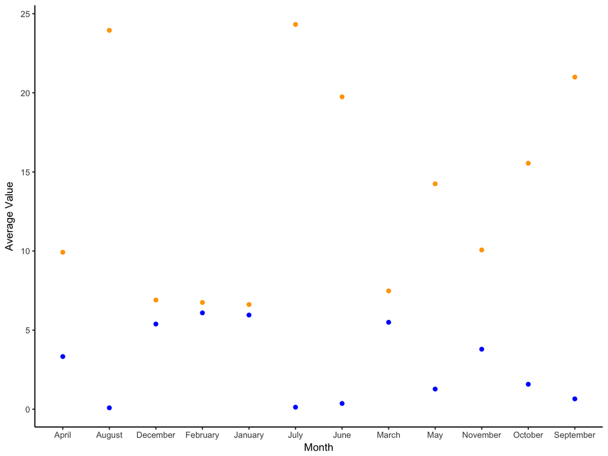

```r
library(ggplot2)
TempRain = read.table("RainTemp.txt", header=T)
View(TempRain)

Final_plot <- ggplot (TempRain) +
  geom_point(aes(x = month, y = avg_monthly_temp), col = "orange")+
  geom_point(aes(x = month, y = avg_monthly_rain), col = "blue")+
  theme_classic(base_size = 10)+
    theme(legend.position = "bottom")+
  labs(x = "Month", y = "Average Value")

Final_plot
```

*We can observe how during the summer months (May, June, July, August) values of rain (in blue) are low while values of temperature (in orange) are high. In the other hand during winter seasons rain and temperature magnitudes come close*